# Os tipos de filmes de Tom Hanks

## A intuição

Uma forma de descrever estrutura nos dados é percebendo grupos de observações mais semelhantes entre si que com o restante dos dados. Agrupamentos.

Por exemplo, observando as avaliações dos filmes:

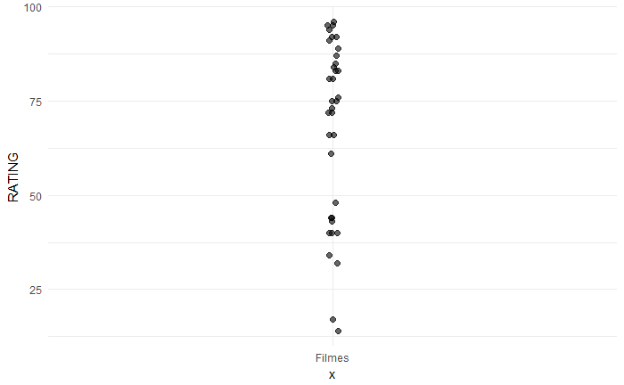

```r
filmes %>%
    ggplot(aes(x = "Filmes", y = RATING)) +
    geom_jitter(width = .01, height = 0, size = 2, alpha = .6)
```

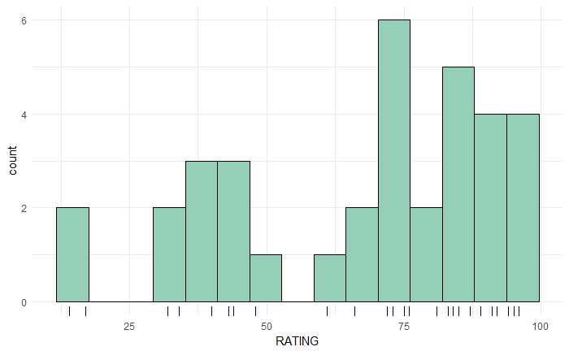

```r
filmes %>%
    ggplot(aes(x = RATING)) +
    geom_histogram(bins = 15,
                   boundary = 0,
                   fill = "#95CFB7",
                   color = "black") +
    geom_rug()
```

Já considerando o ano de lançamento, não há uma estrutura clara de grupos.

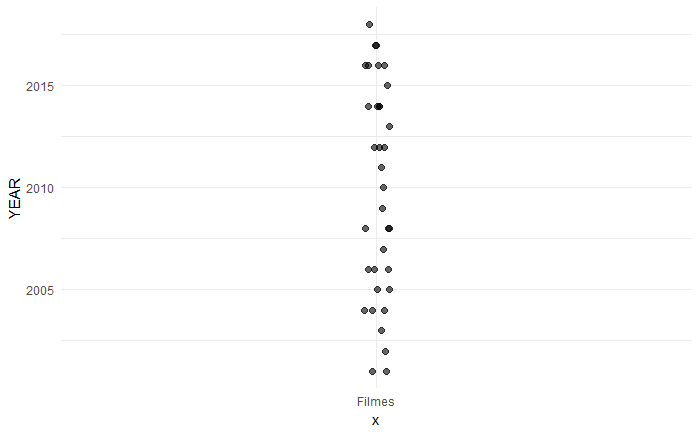

```r
filmes %>%
    ggplot(aes(x = "Filmes", y = YEAR)) +
    geom_jitter(width = .02, height = 0, size = 2, alpha = .6)
```

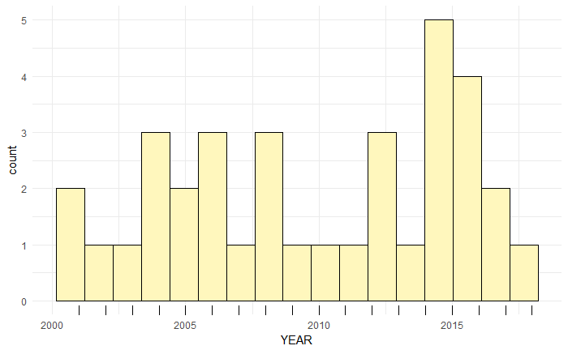

```r
filmes %>%
    ggplot(aes(x = `YEAR`)) +
    geom_histogram(bins = 17,
                   fill = "#FFF7BD",
                   color = "black") +
    geom_rug()
```

Podemos gerar dados sintéticos que tenham tendência de grupos, também.

```r
set.seed(123) # com a mesma semente, o gerador de números aleatórios gera a mesma sequência

t1 = tibble(
    formato = "Sem estrutura de grupos",
    variavel = runif(140, min = -5, max = 100)
)

t2 = tibble(
    formato = "Com estrutura de grupos",
    variavel = c(rnorm(100, mean = 10, sd = 8),
                 rnorm(40, mean = 80, sd = 15))
)

t3 = tibble(
    formato = "Grupos e outliers",
    variavel = c(rnorm(100, mean = 10, sd = 10), 75, 110)
)

bind_rows(t1, t2, t3) %>%
    ggplot(aes(x = formato, y = variavel)) +
    geom_jitter(width = .05, height = 0, size = 2, alpha = .6, color = "#F04155")
```

[output not shown]

## Em que escala estamos analisando estrutura?

Para a renda do filme, observar uma escala linear ou logarítmica levam a conclusões diferentes.

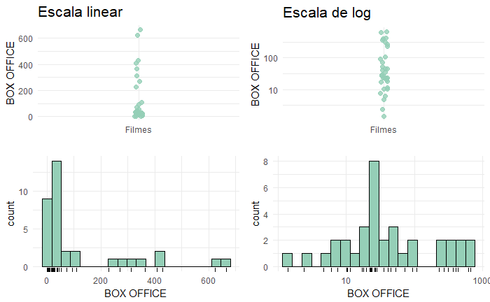

```r
geom_jitter_formatado <- function(){
    geom_jitter(width = .02, height = 0, size = 2, alpha = .8, color = "#95CFB7")
}
geom_histogram_formatado <- function(){
    geom_histogram(bins = 20, fill = "#95CFB7", color = "black")
}

p1 = filmes %>%
    ggplot(aes(x = "Filmes", y = `BOX OFFICE`)) +
    geom_jitter_formatado() +
    labs(title = "Escala linear", x = "")

p2 = filmes %>%
    ggplot(aes(x = "Filmes", y = `BOX OFFICE`)) +
    geom_jitter_formatado() +
    scale_y_log10() +
    labs(title = "Escala de log", x = "")
p3 = filmes %>%
    ggplot(aes(x = `BOX OFFICE`)) +
    geom_histogram_formatado()  +
    geom_rug()
p4 = filmes %>%
    ggplot(aes(x = `BOX OFFICE`)) +
    geom_histogram_formatado()  +
    scale_x_log10() +
    geom_rug()
grid.arrange(p1, p2, p3, p4, ncol = 2)
```

Ver os valores de uma variável numa escala de log é uma técnica muito útil em várias situações de análise de dados. Por isso vale dar uma lida no assunto. Mais explicações sobre escalas logarítmicas, quando/como usá-las e como lê-las [nesse](https://blog.datawrapper.de/weeklychart-logscale2/) e [nesse](https://blog.datawrapper.de/weeklychart-logscale/) posts do pessoal do datawrapper.

## Agrupamento

Para produzir uma solução de agrupamento precisamos de:

- Definição de proximidade/distância entre pontos
- Definição de proximidade/distância entre grupos ou grupos e pontos
- Processo de agrupamento
- Decidir quantos grupos existem

Depois vem o principal: **avaliar e interpretar** a solução. *Agrupamento sempre dá um resultado, mas nem sempre o resultado é útil*.

## Com uma dimensão

Há duas maneiras principais de agrupar: aglomerativa ou baseada em partição. Vamos explorar primeiro a **hierárquica aglomerativa**.

```r
filmes = filmes %>% mutate(i = 1:n())
distancias.long = filmes %>%
    select(RATING) %>%
    dist(method = "euclidean") %>%
    as.matrix %>%
    reshape2::melt(varnames = c("row", "col"))
distancias.long = distancias.long %>%
    left_join(filmes %>% select(i, filme1 = TITLE), by = c("row" = "i")) %>%
    left_join(filmes %>% select(i, filme2 = TITLE), by = c("col" = "i")) %>%
    arrange(row)
distancias.long
```

| row | col | value | filme1 | filme2 |
| --- | --- | --- | --- | --- |
| 1 | 1 | 0 | Avengers: Infinity War | Avengers: Infinity War |
| 1 | 2 | 39 | Avengers: Infinity War | Rough Night |
| 1 | 3 | 39 | Avengers: Infinity War | Ghost in the Shell |
| 1 | 4 | 11 | Avengers: Infinity War | Sing |
| 1 | 5 | 8 | Avengers: Infinity War | Captain America: Civil War |
| 1 | 6 | 12 | Avengers: Infinity War | The Jungle Book |
| 1 | 7 | 2 | Avengers: Infinity War | Hail, Caesar! |
| 1 | 8 | 8 | Avengers: Infinity War | Avengers: Age of Ultron |
| 1 | 9 | 17 | Avengers: Infinity War | Lucy |
| 1 | 10 | 4 | Avengers: Infinity War | Chef |

[output cut: 990 more lines]

```r
row.names(filmes) = NULL
agrupamento_h = filmes %>%
    mutate(TITLE = paste(TITLE, RATING, sep = "-")) %>%
    column_to_rownames("TITLE") %>% # hclust precisa dos rótulos em nomes de linha (ruim)
    select(RATING) %>%
    dist(method = "euclidian") %>%
    hclust(method = "centroid")
```

```
Setting row names on a tibble is deprecated.
```

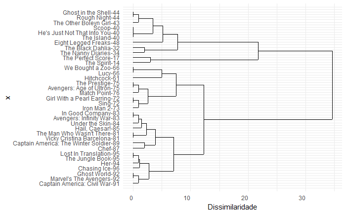

```r
ggdendrogram(agrupamento_h, rotate = T, size = 2, theme_dendro = F) +
    labs(y = "Dissimilaridade")
```

Cada junção é um passo do algoritmo. A altura na dendrograma em cada passo significa a dissimilaridade entre os pontos ou grupos juntados naquele passo, calculado pelo critério de aglomeração.

Na medida que vamos aglomerando, as dissimilaridades nas junções tendem a ir aumentando caso haja estrutura de grupos.

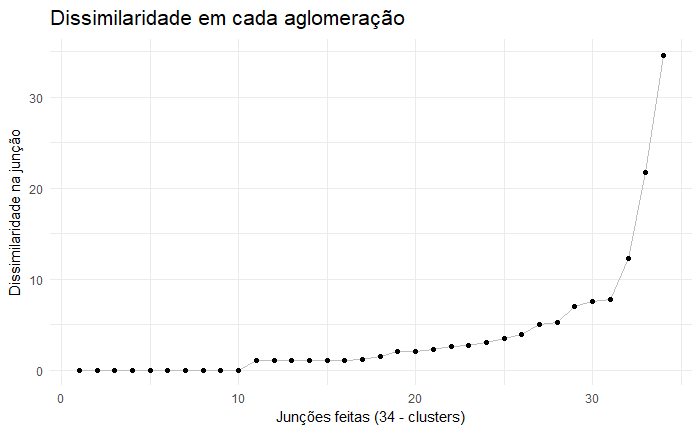

```r
tibble(alturas_dendrograma = agrupamento_h$height) %>%
    mutate(k = 1:n()) %>%
    ggplot(aes(x = k, y = alturas_dendrograma)) +
    geom_line(colour = "grey") +
    geom_point() +
    labs(x = "Junções feitas (34 - clusters)",
         y = "Dissimilaridade na junção",
         title = "Dissimilaridade em cada aglomeração")
```

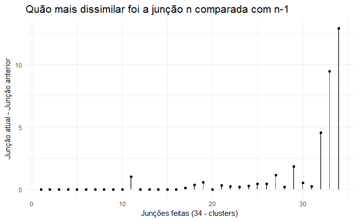

```r
tibble(alturas_dendrograma = agrupamento_h$height) %>%
    mutate(k = 1:n(),
           delta = alturas_dendrograma - lag(alturas_dendrograma, default = 0)) %>%
    ggplot(aes(x = k, y = delta)) +
    geom_col(width = .1) +
    geom_point() +
    labs(x = "Junções feitas (34 - clusters)",
         y = "Junção atual - Junção anterior",
         title = "Quão mais dissimilar foi a junção n comparada com n-1")
```

Onde está o ponto em que as distâncias aglomeradas começa a crescer no dendrograma:

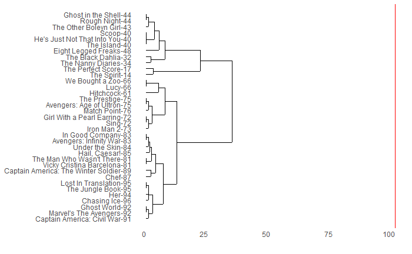

```r
ggdendrogram(agrupamento_h, rotate = T, size = 2) +
    geom_hline(yintercept = 100, colour = "red")
```

## Visualizando os agrupamentos

Vejamos as soluções com diferentes números de grupos.

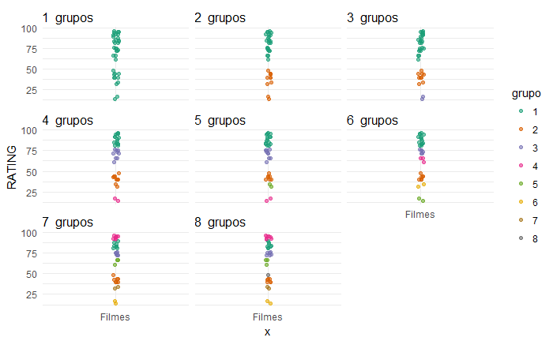

```r
get_grupos <- function(agrupamento, num_grupos){
    agrupamento %>%
        cutree(num_grupos) %>%
        as.data.frame() %>%
        mutate(label = rownames(.)) %>%
        gather(key =  "k", value = "grupo", -label) %>%
        mutate(grupo = as.character(grupo))
}
atribuicoes = get_grupos(agrupamento_h,
                         num_grupos = 1:8)
atribuicoes = atribuicoes %>%
    mutate(TITLE = label %>% word(1, sep = "-")) %>%
    left_join(filmes, by = "TITLE")
atribuicoes %>%
    ggplot(aes(x = "Filmes", y = RATING, colour = grupo)) +
    geom_jitter(width = .02, height = 0, size = 1.6, alpha = .6) +
    facet_wrap(~ paste(k, " grupos")) +
    scale_color_brewer(palette = "Dark2")
```

`stats::heatmap()` é uma função que visualiza distâncias entre pontos organizando linhas e colunas via `hclust`:

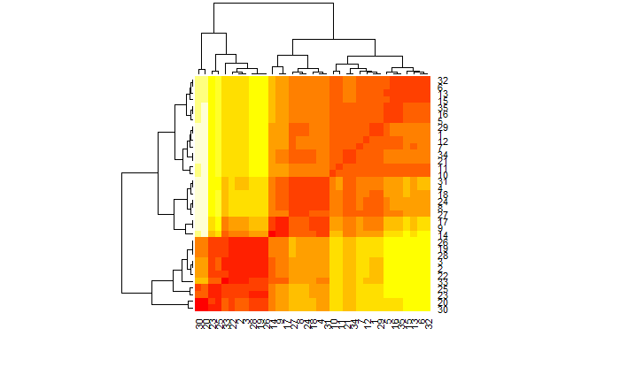

```r
filmes %>%
    select(RATING) %>%
    dist(method = "euclidean") %>%
    as.matrix %>%
    heatmap()
```

### Variando o método de linkage

```r
plota_hclusts_1d(filmes,
                 "RATING",
                 linkage_method = "centroid", # single, complete, average, centroid, median, ...
                 ks = 1:6)
```

[output not shown]

### Com outras variáveis

```r
plota_hclusts_1d(filmes, "YEAR", linkage_method = "centroid", ks = 1:6)
```

[output not shown]

```r
plota_hclusts_1d(filmes, "`BOX OFFICE`", linkage_method = "centroid", ks = 1:6)

filmes %>% mutate(`BOX OFFICE` = log(`BOX OFFICE`)) %>%
    plota_hclusts_1d("`BOX OFFICE`", linkage_method = "centroid", ks = 1:6) +
    scale_y_log10()
```

[output not shown]

## Silhouetas

Dada a distância média de um ponto para os demais do seu cluster $a(i)$ e a distância média do ponto para todos os demais do cluster mais próximo $b(i)$, a largura da silhoueta de $i$ é :

$$s(i) := ( b(i) - a(i) ) / max( a(i), b(i) )$$

Repare como 1 significa uma boa atribuição para $i$, 0 significa indefinição e $-1$ significa que há outro cluster onde $i$ estaria melhor alocado.

```r
distancias = filmes %>%
    select(RATING) %>%
    dist(method = "euclidean")

agrupamento_hs = filmes %>%
    column_to_rownames("TITLE") %>%
    select(RATING) %>%
    dist(method = "euclidean") %>%
    hclust(method = "ward.D")


plot(silhouette(cutree(agrupamento_hs, k = 3), distancias))
plot(silhouette(cutree(agrupamento_hs, k = 2), distancias))
```

[output not shown]

## Duas dimensões

```r
p = filmes %>%
    ggplot(aes(x = RATING,
               y = `BOX OFFICE`,
               label = TITLE)) +
    geom_point()
p
ggplotly(p)
```

[output not shown]

```r
agrupamento_h_2d = filmes %>%
    as.data.frame() %>%
    column_to_rownames("TITLE") %>%
    select(RATING, `BOX OFFICE`) %>%
    dist(method = "euclidean") %>%
    hclust(method = "centroid")

ggdendrogram(agrupamento_h_2d, rotate = TRUE)

data.frame(height = agrupamento_h_2d$height) %>%
    mutate(k = 1:n()) %>%
    ggplot(aes(x = k, y = height)) +
    geom_line(colour = "grey") +
    geom_point() +
    labs(x = "Número de clusters produzido", y = "Dissimilaridade na junção")
```

[output not shown]

```r
plota_hclusts_2d(agrupamento_h_2d,
                 filmes,
                 c("RATING", "`BOX OFFICE`"),
                 linkage_method = "centroid", ks = 1:6)
```

[output not shown]

**Solução: standardize (aka scale).**

```r
agrupamento_h_2d = filmes %>%
    mutate_at(vars(RATING, `BOX OFFICE`),
              funs(scale)) %>%
    as.data.frame() %>%
    column_to_rownames("TITLE") %>%
    select(RATING, `BOX OFFICE`) %>%
    dist(method = "euclidean") %>%
    hclust(method = "centroid")

ggdendrogram(agrupamento_h_2d, rotate = TRUE, theme_dendro = F)

plota_hclusts_2d(agrupamento_h_2d,
                 filmes,
                 c("RATING", "`BOX OFFICE`"),
                 linkage_method = "ward.D", ks = 1:6)
```

[output not shown]

E com escala de log para bilheteria?

```r
agrupamento_h_2d = filmes %>%
    mutate(`BOX OFFICE` = log10(`BOX OFFICE`)) %>%
    mutate_at(vars(RATING, `BOX OFFICE`), funs(scale)) %>%
    as.data.frame() %>%
    column_to_rownames("TITLE") %>%
    select(RATING, `BOX OFFICE`) %>%
    dist(method = "euclidean") %>%
    hclust(method = "ward.D")

ggdendrogram(agrupamento_h_2d, rotate = TRUE, theme_dendro = F)

filmes2 = filmes %>% mutate(`BOX OFFICE` = log10(`BOX OFFICE`))
plota_hclusts_2d(agrupamento_h_2d,
                 filmes2,
                 c("RATING", "`BOX OFFICE`"),
                 linkage_method = "ward.D", ks = 1:6) +
    scale_y_log10() +
    scale_color_brewer(palette = "Dark2")

plota_hclusts_2d(agrupamento_h_2d,
                 filmes2,
                 c("RATING", "`BOX OFFICE`"),
                 linkage_method = "ward.D", ks = 1:6) +
    scale_color_brewer(palette = "Dark2")
```

[output not shown]

```r
agrupamento_h_2d = filmes %>%
    mutate(`BOX OFFICE` = log10(`BOX OFFICE`)) %>%
    mutate_at(vars(RATING, `BOX OFFICE`), funs(scale)) %>%
    as.data.frame() %>%
    column_to_rownames("TITLE") %>%
    select(RATING, `BOX OFFICE`) %>%
    dist(method = "euclidean") %>%
    hclust(method = "ward.D")

distancias = filmes %>%
    column_to_rownames("TITLE") %>%
    select(RATING, `BOX OFFICE`) %>%
    mutate(`BOX OFFICE` = log10(`BOX OFFICE`)) %>%
    mutate_all(funs(scale)) %>%
    dist(method = "euclidean")

plot(silhouette(cutree(agrupamento_h_2d, k = 4), distancias))
```

[output not shown]

## Mais variáveis

E se tivéssemos mais de duas variáveis?

```r
filmes2 = filmes %>%
    mutate(TITLE_LENGTH = nchar(TITLE))

glimpse(filmes2)

dists = filmes2 %>%
    as.data.frame() %>%
    mutate(`BOX OFFICE` = log10(`BOX OFFICE`)) %>%
    mutate_at(vars(RATING,
                   `BOX OFFICE`,
                   TITLE_LENGTH,
                   YEAR),
              funs(scale)) %>%
    column_to_rownames("TITLE") %>%
    select(RATING, `BOX OFFICE`, TITLE_LENGTH, YEAR) %>%
    dist(method = "euclidean")

agrupamento_h_md = dists %>%
    hclust(method = "ward.D")

ggdendrogram(agrupamento_h_md, rotate = T)
```

[output not shown]

```r
tibble(alturas_dendrograma = agrupamento_h_md$height) %>%
    mutate(k = 1:n()) %>%
    ggplot(aes(x = k, y = alturas_dendrograma)) +
    geom_line(colour = "grey") +
    geom_point() +
    labs(x = "Junções feitas (34 - clusters)",
         y = "Dissimilaridade na junção",
         title = "Dissimilaridade em cada aglomeração")
```

[output not shown]

```r
cores = RColorBrewer::brewer.pal(4, "Set3")
plot(cluster::silhouette(cutree(agrupamento_h_md, k = 4), dists), col = cores, border = NA)
```

[output not shown]

```r
filmes2_agrupados = filmes2 %>%
    select(-i) %>%
    mutate(grupo = agrupamento_h_md %>% cutree(4) %>%  as.character())

filmes2_long = filmes2_agrupados %>%
    mutate_at(vars(`BOX OFFICE`), log10) %>%
    mutate_at(vars(`BOX OFFICE`, YEAR, RATING, TITLE_LENGTH), scale) %>%
    gather(key = "variavel", value = "valor", -TITLE, -grupo, -CREDIT)

filmes2_long %>%
    ggplot(aes(x = reorder(variavel, valor), y = valor, group = grupo, colour = grupo)) +
    geom_point(alpha = .4, size = 2, position = position_dodge(width = .5)) +
    labs(x = "", y = "z-score") +
    scale_color_brewer(palette = "Set1")

filmes2_long %>%
    ggplot(aes(x = reorder(variavel, valor), y = valor, group = variavel, colour = variavel)) +
    geom_point(alpha = .4, size = 2, position = position_dodge(width = .5)) +
    labs(x = "", y = "z-score") +
    facet_grid(reorder(grupo, valor, median) ~ . ) +
    coord_flip() +
    scale_color_brewer(palette = "Dark2")
```

[output not shown]

```r
library(plotly)
p <- filmes2_agrupados %>%
    plot_ly(type = 'parcoords',
            line = list(color = ~ grupo),
            dimensions = list(
                list(range = c(1, 4), label = "grupo", values = ~grupo),
                list(range = c(0, 100),
                     label = 'Avaliação', values = ~RATING),
                list(range = c(0, 3),
                     label = 'Bilheteria (log10)', values = ~log10(`BOX OFFICE`)),
                list(range = c(0, 40),
                     label = 'Comprimento título', values = ~TITLE_LENGTH),
                list(range = c(1980, 2020),
                     label = 'Ano', values = ~YEAR)
            )
    )
p
```

[output not shown]